# Exercise 2 – Regression

[Introduction to Machine Learning](https://slds-lmu.github.io/i2ml/)

## Exercise 1: HRO in coding frameworks

**Learning goals**

Throughout the lecture, we will frequently use the `R` package `mlr3`, resp. the `Python` package `sklearn`, and its descendants, providing an integrated ecosystem for all common machine learning tasks. Let’s recap the HRO principle and see how it is reflected in either `mlr3` or `sklearn`. An overview of the most important objects and their usage, illustrated with numerous examples, can be found at [the `mlr3` book](https://mlr3book.mlr-org.com/) and [the `scikit` documentation](https://scikit-learn.org/stable/index.html).

How are the key concepts (i.e., hypothesis space, risk and optimization) you learned about in the lecture videos implemented?

**Solution**

**R**

```r
# You initialize your "learner" or model with its properties defined by the
# parameters, e.g.,:
model <- lrn("regr.lm")
# Before training them on actual data, they just contain information on the
# functional form of f. Once a learner has been trained we can examine the
# parameters of the resulting model.
print(model)
X <- seq(0, 8, by = 0.01)
set.seed(42)
y <- -1 + 3 * X + rnorm(mean = 0, sd = 4, n = length(X))
dt <- data.frame(x = X, y = y)
task <- TaskRegr$new(id = "mytask", backend = dt, target = "y")
# Optimization happens rather implicitly as sklearn only acts as a wrapper for
# existing implementations and calls package-specific optimization procedures
# within the function `model.fit()`:
model$train(task)
sprintf("Model MSE: %f", model$predict_newdata(dt)$score())
```

```
<LearnerRegrLM:regr.lm>
* Model: -
* Parameters: list()
* Packages: mlr3, mlr3learners, stats
* Predict Types:  [response], se
* Feature Types: logical, integer, numeric, character, factor
* Properties: loglik, weights
```

'Model MSE: 15.104770'

**Python**

```python
# You initialize your "learner" or model with its properties defined by the
# parameters, e.g.,:
model = LinearRegression(fit_intercept=True)
# Before training them on actual data, they just contain information on the
# functional form of f. Once a learner has been trained we can examine the
# parameters of the resulting model.
print(model)
x = np.arange(0, 8, 0.01)
np.random.seed(42)
y = -1 + 3*x + np.random.normal(loc=0.0, scale=4, size=len(x))
# Optimization happens rather implicitly as sklearn only acts as a wrapper for
# existing implementations and calls package-specific optimization procedures
# within the function `model.fit()`:
model.fit(x.reshape(-1, 1),y) # reshape for one feature design matrix
print(
    'Model MSE: ', metrics.mean_squared_error(y, model.predict(x.reshape(-1, 1)))
)
```

```
LinearRegression()
Model MSE:  15.461825608784347
```

Have a look at`mlr3::tsk("iris")` / `sklearn.datasets.load_iris`. What attributes does this object store?

**Solution**

**R**

```r
task_iris <- tsk("iris")
sprintf("Feature names: %s", task_iris$feature_names)
sprintf("Target name: %s", task_iris$target_names)
```

1. 'Feature names: Petal.Length'

2. 'Feature names: Petal.Width'

3. 'Feature names: Sepal.Length'

4. 'Feature names: Sepal.Width'

'Target name: Species'

**Python**

```python
iris = load_iris()
X = iris.data
y = iris.target
feature_names = iris.feature_names
target_names = iris.target_names
print("Type of object iris:", type(iris))
print("Feature names:", feature_names)
print("Target names:", target_names)
print("\nShape of X and y\n", X.shape, y.shape)
print("\nType of X and y\n", type(X), type(y))
```

```
Type of object iris: <class 'sklearn.utils._bunch.Bunch'>
Feature names: ['sepal length (cm)', 'sepal width (cm)', 'petal length (cm)', 'petal width (cm)']
Target names: ['setosa' 'versicolor' 'virginica']

Shape of X and y
 (150, 4) (150,)

Type of X and y
 <class 'numpy.ndarray'> <class 'numpy.ndarray'>
```

Instantiate a regression tree learner. What are the different settings for this learner?

**Hint**

**R**

Use `lrn("regr.rpart")` (`mlr3::mlr_learners$keys()` shows all available learners).

**Python**

Use the `DecisionTreeRegressor` module and use `get_params()` to see all available settings.

**Solution**

**R**

```r
# List available learners in base mlr3 package
mlr_learners$keys()

# Inspect regression tree learner
lrn("regr.rpart")

# List configurable hyperparameters
lrn("regr.rpart")$param_set
```

1. 'classif.cv_glmnet'

2. 'classif.debug'

3. 'classif.featureless'

4. 'classif.glmnet'

5. 'classif.kknn'

6. 'classif.lda'

7. 'classif.log_reg'

8. 'classif.multinom'

9. 'classif.naive_bayes'

10. 'classif.nnet'

11. 'classif.qda'

12. 'classif.ranger'

13. 'classif.rpart'

14. 'classif.svm'

15. 'classif.xgboost'

16. 'clust.agnes'

17. 'clust.ap'

18. 'clust.cmeans'

19. 'clust.cobweb'

20. 'clust.dbscan'

21. 'clust.diana'

22. 'clust.em'

23. 'clust.fanny'

24. 'clust.featureless'

25. 'clust.ff'

26. 'clust.hclust'

27. 'clust.kkmeans'

28. 'clust.kmeans'

29. 'clust.MBatchKMeans'

30. 'clust.mclust'

31. 'clust.meanshift'

32. 'clust.pam'

33. 'clust.SimpleKMeans'

34. 'clust.xmeans'

35. 'regr.cv_glmnet'

36. 'regr.debug'

37. 'regr.featureless'

38. 'regr.glmnet'

39. 'regr.kknn'

40. 'regr.km'

41. 'regr.lm'

42. 'regr.nnet'

43. 'regr.ranger'

44. 'regr.rpart'

45. 'regr.svm'

46. 'regr.xgboost'

```
<LearnerRegrRpart:regr.rpart>: Regression Tree
* Model: -
* Parameters: xval=0
* Packages: mlr3, rpart
* Predict Types:  [response]
* Feature Types: logical, integer, numeric, factor, ordered
* Properties: importance, missings, selected_features, weights
```

```
<ParamSet>
                id    class lower upper nlevels        default value
 1:             cp ParamDbl     0     1     Inf           0.01
 2:     keep_model ParamLgl    NA    NA       2          FALSE
 3:     maxcompete ParamInt     0   Inf     Inf              4
 4:       maxdepth ParamInt     1    30      30             30
 5:   maxsurrogate ParamInt     0   Inf     Inf              5
 6:      minbucket ParamInt     1   Inf     Inf <NoDefault[3]>
 7:       minsplit ParamInt     1   Inf     Inf             20
 8: surrogatestyle ParamInt     0     1       2              0
 9:   usesurrogate ParamInt     0     2       3              2
10:           xval ParamInt     0   Inf     Inf             10     0
```

**Python**

```python
# help(DecisionTreeRegressor)

# Inspect regression tree learner
rtree = DecisionTreeRegressor() # default setting
print(rtree)

# List configurable hyperparameters
[print(f'{k}: {v}') for k, v in rtree.get_params().items()][0]
```

```
DecisionTreeRegressor()
ccp_alpha: 0.0
criterion: squared_error
max_depth: None
max_features: None
max_leaf_nodes: None
min_impurity_decrease: 0.0
min_samples_leaf: 1
min_samples_split: 2
min_weight_fraction_leaf: 0.0
random_state: None
splitter: best
```

## Exercise 2: Loss functions for regression tasks

**Learning goals**

In this exercise, we will examine loss functions for regression tasks somewhat more in depth.

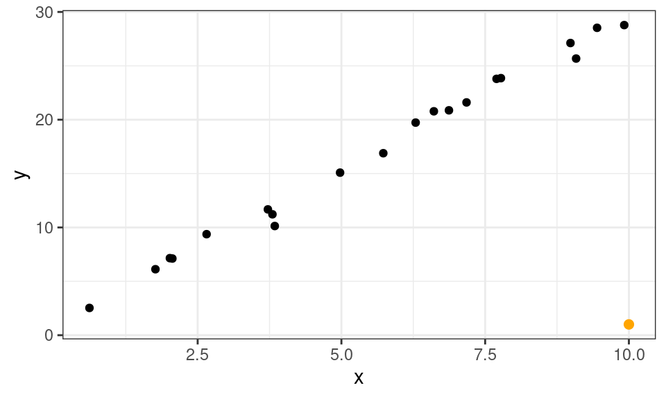

Consider the above linear regression task. How will the model parameters be affected by adding the new outlier point (orange) if you use $L1$ loss and $L2$ loss, respectively, in the empirical risk? (You do not need to actually compute the parameter values.)

**Solution**

$L2$ loss penalizes vertical distances to the regression line *quadratically*, while $L1$ only considers the *absolute* distance. As the outlier point lies pretty far from the remaining training data, it will have a large loss with $L2$, and the regression line will pivot to the bottom right to minimize the resulting empirical risk. A model trained with $L1$ loss is less susceptible to the outlier and will adjust only slightly to the new data.

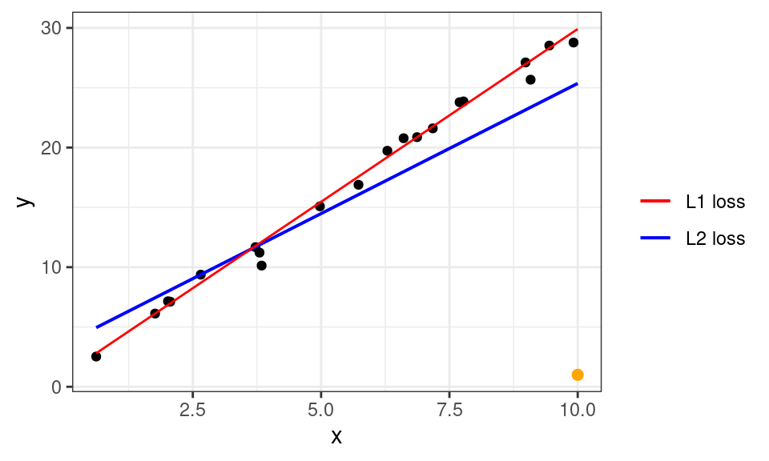

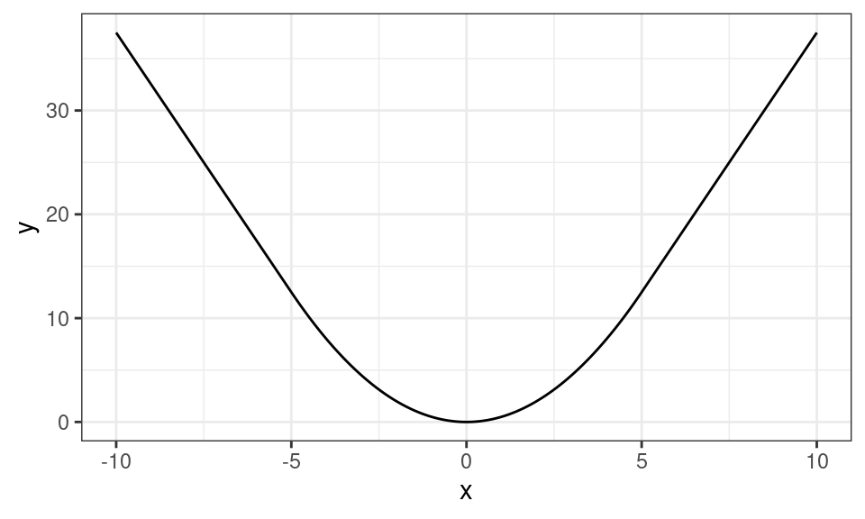

The second plot visualizes another loss function popular in regression tasks, the so-called *Huber loss* (depending on $\epsilon > 0$; here: $\epsilon = 5$). Describe how the Huber loss deals with residuals as compared to $L1$ and $L2$ loss. Can you guess its definition?

**Solution**

The Huber loss combines the respective advantages of $L1$ and $L2$ loss: it is smooth and (once) differentiable like $L2$ but does not punish larger residuals as severely, leading to more robustness. It is simply a (weighted) piecewise combination of both losses, where $\epsilon$ marks where $L2$ transits to $L1$ loss. The exact definition is:
$$L\left(y, f(\mathbf{x})\right)= \begin{cases}
\frac{1}{2}(y - f(\mathbf{x}))^2 & \text{ if } |y - f(\mathbf{x})|\le \epsilon \\
\epsilon |y - f(\mathbf{x})|-\frac{1}{2}\epsilon^2 \quad & \text{ otherwise }
\end{cases}, \quad \epsilon > 0$$
In the plot we can see how the parabolic shape of the loss around 0 evolves into an absolute-value function at $|y - f(\mathbf{x})|> \epsilon = 5$.

## Exercise 3: Polynomial regression

**Learning goals**

Assume the following (noisy) data-generating process from which we have observed 50 realizations:
$$y = -3 + 5 \cdot
\sin(0.4 \pi x) + \epsilon$$
with $\epsilon \, \sim \mathcal{N}(0, 1)$.

We decide to model the data with a cubic polynomial (including intercept term). State the corresponding hypothesis space.

**Solution**

Cubic means degree 3, so our hypothesis space will look as follows:
$$\mathcal{H}= \{ f(\mathbf{x}~|~ \boldsymbol{\theta})= \theta_0 + \theta_1 x + \theta_2 x^2 + \theta_3 x^3
~|~ (\theta_0, \theta_1, \theta_2, \theta_3)^\top \in \mathbb{R}^4 \}$$

State the empirical risk w.r.t. $\boldsymbol{\theta}$ for a member of the hypothesis space. Use $L2$ loss and be as explicit as possible.

**Solution**

The empirical risk is:
$$\mathcal{R}_{\text{emp}}(\boldsymbol{\theta})= \sum_{i = 1}^{50} \left(y^{(i)}- \left[ \theta_0 + \theta_1 x^{(i)} +
\theta_2 \left( x^{(i)} \right)^2 + \theta_3 \left( x^{(i)} \right)^3 \right]
\right)^2$$

**Only for lecture group A**

We can minimize this risk using gradient descent. Derive the gradient of the empirical risk w.r.t $\boldsymbol{\theta}$.

**Solution**

We can find the gradient just as we did for an intermediate result when we derived the least-squares estimator:

$$\begin{align*}
\nabla_{\boldsymbol{\theta}} \mathcal{R}_{\text{emp}}(\boldsymbol{\theta})&=
\frac{\partial{}}{\partial \boldsymbol{\theta}} \left \| \mathbf{y}- \mathbf{X}\boldsymbol{\theta}\right \|_2^2 \\
&= \frac{\partial{}}{\partial \boldsymbol{\theta}} \left( \left(\mathbf{y}- \mathbf{X}\boldsymbol{\theta}\right)^\top
\left(\mathbf{y}- \mathbf{X}\boldsymbol{\theta}\right) \right) \\
&= - 2 \mathbf{X}^\top \mathbf{y}+ 2 \mathbf{X}^\top \mathbf{X}\boldsymbol{\theta}\\
&= 2 \cdot \left( - \mathbf{X}^\top \mathbf{y}+ \mathbf{X}^\top
\mathbf{X}\boldsymbol{\theta}\right)
\end{align*}$$

**Only for lecture group A**

Using the result for the gradient, state the calculation to update the current parameter $\boldsymbol{\theta}^{[t]}$.

**Solution**

Recall that the idea of gradient descent (!) is to traverse the risk surface in the direction of the gradient as we are in search for the minimum. Therefore, we will update our current parameter set $\boldsymbol{\theta}^{[t]}$ with the negative gradient of the current empirical risk w.r.t. $\boldsymbol{\theta}$, scaled by learning rate (or step size) $\alpha$:

$$\boldsymbol{\theta}^{[t +1]}= \boldsymbol{\theta}^{[t]}- \alpha \cdot \nabla_{\boldsymbol{\theta}} \mathcal{R}_{\text{emp}}(\boldsymbol{\theta}^{[t]}).$$

$$\begin{align*}
\underbrace{\boldsymbol{\theta}^{[t +1]}}_{p \times 1} &= \underbrace{\boldsymbol{\theta}^{[t]}}_{p \times 1} -
\tilde \alpha \cdot \left( - \underbrace{\mathbf{X}^\top \phantom{y}}_{
p \times n} \underbrace{\mathbf{y}}_{n \times 1} + \underbrace{
\mathbf{X}^\top \mathbf{X}\phantom{y}}_{p \times p}
\underbrace{\boldsymbol{\theta}^{[t]}\phantom{y}}_{p \times 1}
\right) \\
\begin{pmatrix} \theta_1 \\ \theta_2 \\ \vdots \\ \theta_p \end{pmatrix}^{[t + 1]} &=
\begin{pmatrix} \theta_1 \\ \theta_2 \\ \vdots \\ \theta_p \end{pmatrix}^{[t]} - \tilde \alpha
\cdot \left( - \mathbf{X}^\top \mathbf{y}+ \mathbf{X}^\top \mathbf{X}
\begin{pmatrix} \theta_1 \\ \theta_2 \\ \vdots \\ \theta_p \end{pmatrix}^{[t]} \right)
\end{align*}$$

In order to see what that means it is helpful to recall that the gradient $\nabla_{\boldsymbol{\theta}} \mathcal{R}_{\text{emp}}(\boldsymbol{\theta})$ tells us about the effect (infinitesimally small) changes in $\boldsymbol{\theta}$ have on $\mathcal{R}_{\text{emp}}(\boldsymbol{\theta})$. Therefore, gradient updates focus on influential components, and we proceed more quickly along the important dimensions.

You will not be able to fit the data perfectly with a cubic polynomial. Describe the advantages and disadvantages that a more flexible model class would have. Would you opt for a more flexible learner?

**Solution**

- We would be able to trace the observations more closely if our function were less smooth, and thus reduce empirical risk. On the other hand, flexibility also has drawbacks:
- Flexible model classes often have more parameters, making training harder.
- We might run into a phenomenon called *overfitting*. Recall that our ultimate goal is to make predictions on *new* observations. However, fitting every quirk of the training observations – possibly caused by imprecise measurement or other factors of randomness/error – will not generalize so well to new data.

In the end, we need to balance model fit and generalization. We will discuss the choice of hypotheses quite a lot since it is one of the most crucial design decisions in machine learning.

## Exercise 4: Predicting `abalone`

**Learning goals**

We want to predict the age of an abalone using its longest shell measurement and its weight. The `abalone` data can be found here: https://archive.ics.uci.edu/ml/machine-learning-databases/abalone/abalone.data.

Prepare the data as follows:

**R**

```r
# Download data
url <- "https://archive.ics.uci.edu/ml/machine-learning-databases/abalone/abalone.data"
abalone <- read.table(url, sep = ",", row.names = NULL)
colnames(abalone) <- c(
  "sex", "longest_shell", "diameter", "height", "whole_weight",
  "shucked_weight", "visceral_weight", "shell_weight", "rings"
)

# Reduce to relevant columns
abalone <- abalone[, c("longest_shell", "whole_weight", "rings")]
```

**Python**

Plot `LongestShell` and `WholeWeight` on the $x$- and $y$-axis, respectively, and color points according to `Rings`.

**Solution**

**R**

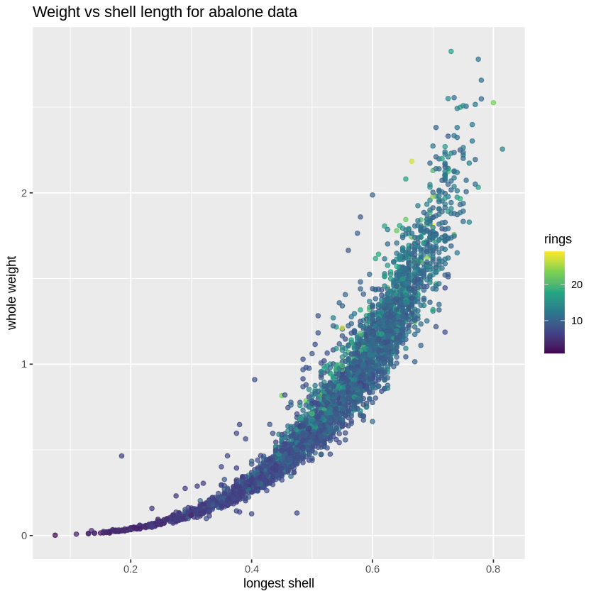

```r
library(ggplot2)

# Plot weight vs shell length
ggplot2::ggplot(
  abalone,
  aes(x = longest_shell, y = whole_weight, col = rings)) +
  ggplot2::geom_point(alpha = 0.7) +
  ggplot2::scale_color_viridis_c() +
  ggplot2::labs(
    x = "longest shell",
    y = "whole weight",
    title = "Weight vs shell length for abalone data"
  )
```

**Python**

Using `mlr3`/`sklearn`, fit a linear regression model to the data.

**Solution**

**R**

```r
library(mlr3)

# Specify regression task
task_abalone <- TaskRegr$new(
  id = "abalone", backend = abalone, target = "rings"
)
task_abalone
```

```
<TaskRegr:abalone> (4177 x 3)
* Target: rings
* Properties: -
* Features (2):
  - dbl (2): longest_shell, whole_weight
```

.

```r
library(mlr3)
library(mlr3learners)

# Set up LM, train (by default, the target will be regressed on all features,
# i.e., target ~ .)
learner_lm <- mlr3::lrn("regr.lm")
print("Model before training:")
learner_lm$model

# Train and predict
learner_lm$train(task_abalone)
print("Model after training:")
learner_lm$model
pred_lm <- learner_lm$predict(task_abalone)

# Inspect predictions
print("Predictions:")
pred_lm
```

```
[1] "Model before training:"
[1] "Model after training:"
[1] "Predictions:"
```

```
Call:
stats::lm(formula = task$formula(), data = task$data())

Coefficients:
  (Intercept)  longest_shell   whole_weight
        3.431         10.582          1.155
```

```
<PredictionRegr> for 4177 observations:
    row_ids truth  response
          1    15  8.840042
          2     7  7.395659
          3     9  9.821995
---
       4175     9 11.139128
       4176    10 11.309553
       4177    12 13.195460
```

**Python**

Compare the fitted and observed targets visually.

**Hint**

**R**

Use `$autoplot()` from `mlr3viz`.

**Python**

**Solution**

**R**

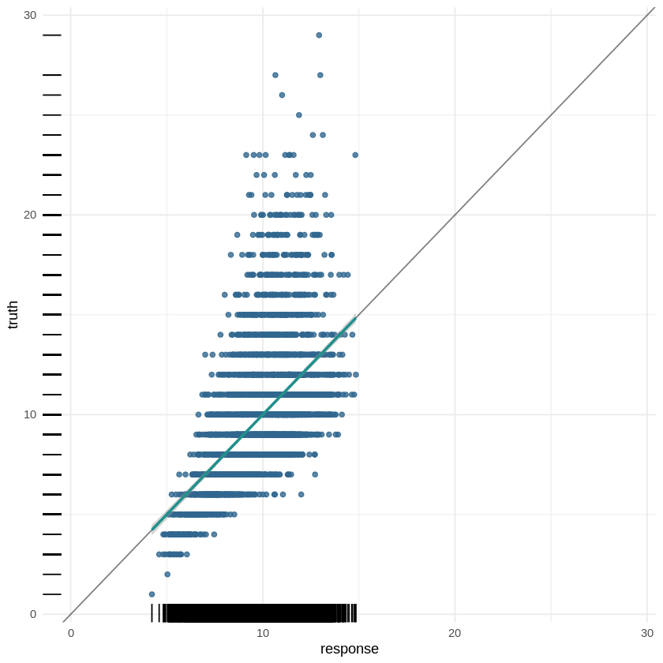

```r
library(mlr3viz)

# Get nice visualization with a one-liner
mlr3viz::autoplot(pred_lm) +
  xlim(c(0, max(abalone$rings)))
```

**Python**

Assess the model’s training loss in terms of MAE.

**Hint**

**R**

Call `$score()`, which accepts different `mlr_measures`, on the prediction object.

**Python**

Call `from sklearn.metrics import mean_absolute_error`.

**Solution**

**R**

```r
# Define MAE metric
mae <- mlr3::msr("regr.mae")

# Assess performance (MSE by default)
pred_lm$score()
pred_lm$score(mae)
```

**regr.mse:** 7.12552086050315

**regr.mae:** 1.95066028734684

**Python**